# CFIT and Nback Analysis

Leandro Ledesma

2024-02-16

### Our Measures of Interest

We are interested in investigating whether performance on the CFIT can explain some of the outcome variance of Nback performance. Initially, there has been a large interest in the literature to compare working memory and intelligence, and for a while some argued it was the same construct. More papers later showed this was not the case, however, I am certainly positive that most IQ and Working Memory measures do not involve the CFIT and the Nback- instead they would use either verbal measures of IQ or Raven’s Progressive Matrices. For Working Memory, more simpler and shorter tasks would be used instead of the Nback like Digit Span task (Tbh I could be wrong I haven’t read these types of papers in like more than a year). Anyway there is something useful here that can add to the literature about the relationship between IQ and working memory. Additionally, this is the type of research that the military really enjoys- thus this would have a good shot of making it through the abstract selection process.

### CFIT

The CFIT stands for the Cultural Fair Intelligence Test. It is comprised of four subtests that are presented in the following order: Series, Classification, Matrices and Conditions. All of these tests are timed and measure a different aspect of non-verbal IQ. Additionally, the number of items per tests are also different. Series has 12 items, Classification has 14, Matrices has 12 and Conditions has 8. The CFIT is scored by summing all correct items from all tests into one raw score. It can then be transformed into an IQ score once considering a person’s age. Unfortunately, the CFIT has different scales (measures the difficulty of the items) and forms (A or A + B). We are using Scale 2 (medium difficulty) and Form B. The problem is that there currently only two methods to standardized raw scores to IQ scores for the Scale 2, and that is by having Scale 2 Form A raw scores of the cumulative raw score of Scale 2 Form A and B. We only have Scale 2 Form B, so we cannot do this. Thus, our values will be simply CFIT raw scores.

### Nback

The Nback is a paradigm that measures working memory. The ‘N’ in Nback is a placeholder for a number. In our case, that number is 2, which means that target trials are items that were seen two items ago. Additionally, our task was done in a VR system and there are four different versions of it. Additionally, this dataset contains the performance of the Nback for a practice day, baseline, and two stress conditions. We are only interested in baseline day (Day 1), so only those testing sessions will be kept in the analysis. Additionally, I may want to incorporate reaction time into thus analysis too but not sure yet how to go about it. According to the internet, the best approach to measure both ideas is to use Bayesian statistics (Linear Ballistic Accumulator)- unfortunately I don’t think I can learn that in the next couple of days so we will be improvising.

### Cross sectional analysis

We will be doing a regression to see if the raw CFIT scores can predict a significant amount of the variance in the Nback performance. To do this, we will be constructing two models. One that scores working memory as the percentage of target trials marked correctly and the other as d prime, which takes into account performance both on target trials and non-target trials in the Nback. I might create a few more models that do this for reaction times as well- we’ll see.

### Hypotheses

There are very to the point hypotheses. Subjects with higher CFIT raw scores will have better accuracy in the Nback and likely faster reaction times on correct trials.

### Universal block code settings

```r
knitr::opts_chunk$set(echo = TRUE)
knitr::opts_chunk$set(message = FALSE)
knitr::opts_chunk$set(comment = NULL)
```

### Load in the data manipulation packages first

```r
library(tidyverse)
library(ggplot2)
library(ggpubr)
library(readxl)
library(lmtest) # bptest() function for homoscedasticity
library(kableExtra)
library(boot)
```

### Load in the data

As mentioned above, we are only interested in performance on Day 1 for the ‘Colors and Shape’ block session for the GnG and the forward arrows no distractor condition in the Nback. Thus, these data will remain for the rest of the analysis.

```r
# Set working directory
setwd("~/ONR/IQ_data/Processed Data")

# Save the data
CFIT <- read.csv("CFIT.raw.scores.csv")

# Data cleaning
CFIT <- CFIT %>% select(-X)

# Set working directory
setwd("C:/Users/lledesma.TIMES/Documents/ONR/GnG_and_Nback_behavioral_data_preprocessing/Processed Data")

# Load in the Nback data (Reacted)
Nback.reacted <- read.csv("Nback.target.reacted.csv")

# Data cleaning- we are only interested in Day 1
Nback.performance <- Nback.reacted %>% filter(Day.Type == "Day 1" & BlockName == "2-Back AR w ND")

# Load Nback reaction time data
Nback.RT <- read.csv("Nback.reaction.time.csv")

# Data cleaning- we are only interested in Day 1, in BlockName 2-Back AR w ND, for only correct trials of the target
Nback.RT <- Nback.RT %>%
  filter(Day.Type == "Day 1" & BlockName == "2-Back AR w ND" & Correct == 1 & Trial.Type == "Target") %>%
  select(-Correct)

# Adding demographic data
setwd("C:/Users/lledesma.TIMES/Documents/ONR/Demographics")

# Save the data as a CSV
demographics <- read.csv("complete.demographics.csv")

# Clean demographics
demographics <- demographics %>%
  select(-email)
```

### Merge the datasets together

Here we will merge our datasets to include demographic information, the raw scores from our CFIT, and our performance on the Nback in Day 1 VR.

```r
# merge the inhibition datasets
Nback.performance.merged <- Nback.performance %>%
  rename(ID = UserID) %>%
  merge(CFIT, by = "ID") %>%
  merge(demographics, by = "ID")

# merge the working memory datasets
Nback.reaction.time.merged <- Nback.RT %>%
  rename(ID = UserID) %>%
  merge(CFIT, by = "ID")  %>%
  merge(demographics, by = "ID")
```

### Getting to know our data (Sample size, etc.)

```r
# This is what it looks like
Nback.performance.merged %>%
  head(10)  %>%
  kbl() %>%
  kable_paper(full_width = F)
```

| ID | BlockName | Trial.Type | Day.Type | target.mean.reacted | trial.num | CFIT | race | ethnicity | Sex | Age |
| --- | --- | --- | --- | --- | --- | --- | --- | --- | --- | --- |
| 1 | 2-Back AR w ND | Target | Day 1 | 0.72 | 32 | 45 | White | Not Hispanic or Latino | Female | 21 |
| 1 | 2-Back AR w ND | First/Second Trial | Day 1 | 0.00 | 16 | 45 | White | Not Hispanic or Latino | Female | 21 |
| 1 | 2-Back AR w ND | Non-Target | Day 1 | 0.01 | 112 | 45 | White | Not Hispanic or Latino | Female | 21 |
| 2 | 2-Back AR w ND | Non-Target | Day 1 | 0.01 | 112 | 37 | Asian | Not Hispanic or Latino | Male | 21 |
| 2 | 2-Back AR w ND | First/Second Trial | Day 1 | 0.06 | 16 | 37 | Asian | Not Hispanic or Latino | Male | 21 |
| 2 | 2-Back AR w ND | Target | Day 1 | 0.88 | 32 | 37 | Asian | Not Hispanic or Latino | Male | 21 |
| 3 | 2-Back AR w ND | First/Second Trial | Day 1 | 0.00 | 16 | 36 | White | Not Hispanic or Latino | Female | 20 |
| 3 | 2-Back AR w ND | Target | Day 1 | 0.38 | 32 | 36 | White | Not Hispanic or Latino | Female | 20 |
| 3 | 2-Back AR w ND | Non-Target | Day 1 | 0.01 | 112 | 36 | White | Not Hispanic or Latino | Female | 20 |
| 4 | 2-Back AR w ND | First/Second Trial | Day 1 | 0.00 | 16 | 34 | Asian | Not Hispanic or Latino | Male | 19 |

```r
# Missing data
Nback.missing.data <- Nback.performance.merged %>%
  select(-c(race, ethnicity)) %>%
  filter(!complete.cases(.))

paste("We have:",nrow(Nback.missing.data),"missing data for the inhibition dataset- not including demographic")
```

```
[1] "We have: 0 missing data for the inhibition dataset- not including demographic"
```

```r
# The dimensions
dim(Nback.performance.merged)
```

```
[1] 537  11
```

```r
# Testing day types present
unique(Nback.performance.merged$Day.Type)
```

```
[1] "Day 1"
```

```r
# Types of GnG versions present
unique(Nback.performance.merged$BlockName)
```

```
[1] "2-Back AR w ND"
```

```r
# Types of stimuli present
unique(Nback.performance.merged$Trial.Type)
```

```
[1] "Target"             "First/Second Trial" "Non-Target"
```

```r
# Trial numbers per trial type
Nback.performance.merged %>%
  group_by(Trial.Type, trial.num) %>%
  count()
```

```
# A tibble: 9 × 3
# Groups:   Trial.Type, trial.num [9]
  Trial.Type         trial.num     n
  <chr>                  <int> <int>
1 First/Second Trial        14     1
2 First/Second Trial        16   177
3 First/Second Trial        20     1
4 Non-Target                98     1
5 Non-Target               112   177
6 Non-Target               140     1
7 Target                    28     1
8 Target                    32   177
9 Target                    40     1
```

```r
# Sample size
paste("Our sample size for the Nback data is:", length(unique(Nback.performance.merged$ID)))
```

```
[1] "Our sample size for the Nback data is: 178"
```

```r
# Now do the same with the reaction time data frame
Nback.reaction.time.merged %>%
  head(10)  %>%
  kbl() %>%
  kable_paper(full_width = F)
```

| ID | Trial.Type | BlockName | Day.Type | mean.RT | CFIT | race | ethnicity | Sex | Age |
| --- | --- | --- | --- | --- | --- | --- | --- | --- | --- |
| 1 | Target | 2-Back AR w ND | Day 1 | 903.4176 | 45 | White | Not Hispanic or Latino | Female | 21 |
| 2 | Target | 2-Back AR w ND | Day 1 | 866.8150 | 37 | Asian | Not Hispanic or Latino | Male | 21 |
| 3 | Target | 2-Back AR w ND | Day 1 | 911.1658 | 36 | White | Not Hispanic or Latino | Female | 20 |
| 4 | Target | 2-Back AR w ND | Day 1 | 793.8854 | 34 | Asian | Not Hispanic or Latino | Male | 19 |
| 6 | Target | 2-Back AR w ND | Day 1 | 899.1174 | 35 | Asian | Not Hispanic or Latino | Female | 21 |
| 9 | Target | 2-Back AR w ND | Day 1 | 913.2330 | 35 | Asian | Not Hispanic or Latino | Female | 30 |
| 10 | Target | 2-Back AR w ND | Day 1 | 896.1827 | 38 | Asian | Not Hispanic or Latino | Female | 19 |
| 11 | Target | 2-Back AR w ND | Day 1 | 921.4640 | 35 | White | Not Hispanic or Latino | Female | 20 |
| 12 | Target | 2-Back AR w ND | Day 1 | 921.9423 | 35 | Black or African American | Hispanic or Latino | Female | 20 |
| 13 | Target | 2-Back AR w ND | Day 1 | 915.7044 | 35 | Asian | Not Hispanic or Latino | Male | 23 |

```r
# Missing data
Nback.missing.data2 <- Nback.performance.merged %>%
  select(-c(race, ethnicity)) %>%
  filter(!complete.cases(.))

paste("We have:",nrow(Nback.missing.data2),"missing data for the inhibition dataset- not including demographic")
```

```
[1] "We have: 0 missing data for the inhibition dataset- not including demographic"
```

```r
# The dimensions
dim(Nback.reaction.time.merged)
```

```
[1] 177  10
```

```r
# Testing day types present
unique(Nback.reaction.time.merged$Day.Type)
```

```
[1] "Day 1"
```

```r
# Types of Nback versions present
unique(Nback.reaction.time.merged$BlockName)
```

```
[1] "2-Back AR w ND"
```

```r
# Trial numbers per trial type
Nback.reaction.time.merged %>%
  group_by(Trial.Type) %>%
  count()
```

```
# A tibble: 1 × 2
# Groups:   Trial.Type [1]
  Trial.Type     n
  <chr>      <int>
1 Target       177
```

```r
# Sample size
paste("Our sample size for the Nback data is:", length(unique(Nback.reaction.time.merged$ID)))
```

```
[1] "Our sample size for the Nback data is: 176"
```

### Demographic information

We have a pretty diverse population, with the Asian, White, and African American making up more than 80% of the sample. Around one third of our participants are Hispanic. There are slightly more males than females in our sample and one intersex person. Lastly our sample is mostly made up of 19-24 years old, with fewer subject being older than this but not older than 35.

```r
# Demographic information for inhibition data set
# Race
Nback.performance.merged$race %>%
  table() %>%
  prop.table() %>%
  stack() %>%
  select(Race = ind, Proportion = values) %>%
  arrange(Proportion) %>%
  mutate(Proportion = round(Proportion,2))
```

```
                                 Race Proportion
1 Native Hawaiian or Pacific Islander       0.01
2   American Indian or Alaskan Native       0.03
3                               Other       0.06
4                  More than one race       0.08
5           Black or African American       0.19
6                               Asian       0.31
7                               White       0.33
```

```r
# Ethnicity
Nback.performance.merged$ethnicity %>%
  table() %>%
  prop.table() %>%
  stack() %>%
  select(Ethnicity = ind, Proportion = values) %>%
  arrange(Proportion) %>%
  mutate(Proportion = round(Proportion,2))
```

```
               Ethnicity Proportion
1     Hispanic or Latino       0.31
2 Not Hispanic or Latino       0.69
```

```r
# Sex
Nback.performance.merged$Sex %>%
  table() %>%
  prop.table() %>%
  stack() %>%
  select(Sex = ind, Proportion = values) %>%
  arrange(Proportion) %>%
  mutate(Proportion = round(Proportion,2))
```

```
             Sex Proportion
1 Intersex/Other       0.01
2         Female       0.45
3           Male       0.55
```

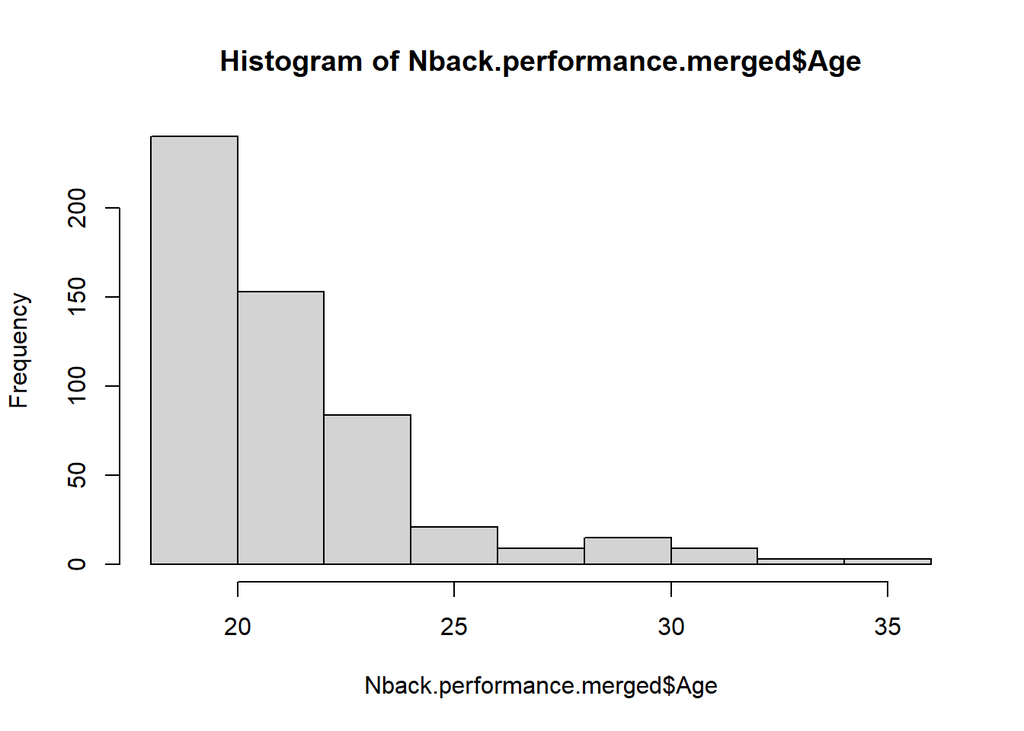

```r
# Age
hist(Nback.performance.merged$Age)
```

```r
# Age descriptive statistics
mean(Nback.performance.merged$Age)
```

```
[1] 21.60335
```

```r
sd(Nback.performance.merged$Age)
```

```
[1] 3.063542
```

### Statistical Approach

Our predictor and outcome variable are both continuous values, however, in terms of our accuracy analysis we will be creating two models. They will both be regressions, except for one of our models our outcome variable (Nback performance) will be calculated by the proportion of correct target trials and in the other model, Nback performance will be defined as d prime. We will most likely go with the results of the latter model, since it incorporates performance from the target trial while also controlling for false alarm rate. This is important since d prime can function as a tie breaker between two subjects that both perform the same during target trials but have differences in their false alarm rate, the participant with the lower false alarm rate will be ranked as the better performer, and d prime does this. Our predictor variable will be the raw scores of the CFIT.

Our second statistical approach will also include continuous variables. Our predictor will be the raw scores of the CFIT and our outcome variable will be the reaction time of correct target trials. Thus, this dataset contains the mean reaction time for only correct target trials. We will use a regression to see if potentially higher CFIT raw scores indicate faster reaction times.

Third analysis- while taking into account d prime and reaction time as one outcome variable is too complex for this abstract, we can at least try to look at the relationship between CFIT scores, d prime, and reaction time by making creating groupings? We could .. not sure yet.

### Models for accuracy

Let’s start by creating our accuracy models and plotting them in a scatterplot.

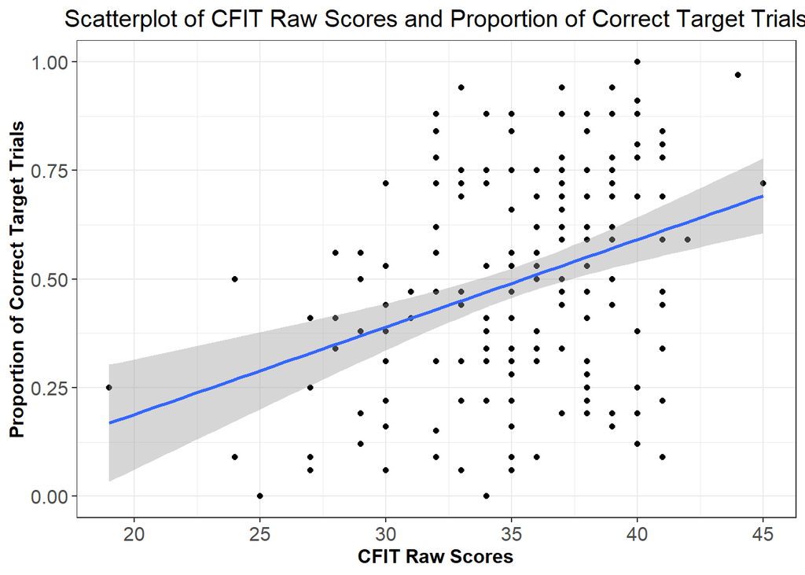

```r
# Create a scatterplot
Nback.performance.merged %>%
  filter(Trial.Type == "Target") %>%
  ggplot(aes(x = CFIT, y = target.mean.reacted)) +
  geom_point() +
  geom_smooth(method = "lm") +
  theme_bw() +
  labs(title = "Scatterplot of CFIT Raw Scores and Proportion of Correct Target Trials",
       x = "CFIT Raw Scores",
       y = "Proportion of Correct Target Trials") +
  theme(plot.title = element_text(size = 15,
                                  hjust = 0.5),
        axis.title = element_text(size = 12, face = "bold"),
        axis.text = element_text(size = 12))
```

SO far this looks promising.

### Calculating d prime

d prime is calculated by taking the difference of the z-score for the proportion correct target trials by the z-score of false alarm rates. The outcome variable will then be numbers that range between positive and negative numbers. The higher the d prime value, the better the subject did in terms of target trial accuracy and minimizing false alarms.

```r
# Calculating d prime
Nback.data.wide <- Nback.performance.merged %>%
  select(-trial.num) %>%
  pivot_wider(names_from = Trial.Type, values_from = target.mean.reacted) %>%
  rename(Hit.rate = Target, False.Alarm.Rate = `Non-Target`)

# View the range of scales for the target performance
Nback.data.wide$Hit.rate %>% sort()
```

```
  [1] 0.00 0.00 0.06 0.06 0.06 0.06 0.06 0.09 0.09 0.09 0.09 0.09 0.09 0.12 0.12
 [16] 0.15 0.16 0.16 0.16 0.19 0.19 0.19 0.19 0.19 0.22 0.22 0.22 0.22 0.22 0.22
 [31] 0.22 0.22 0.25 0.25 0.25 0.25 0.25 0.25 0.28 0.28 0.28 0.31 0.31 0.31 0.31
 [46] 0.31 0.31 0.31 0.34 0.34 0.34 0.34 0.34 0.34 0.34 0.34 0.38 0.38 0.38 0.38
 [61] 0.38 0.38 0.38 0.38 0.41 0.41 0.41 0.41 0.41 0.41 0.41 0.41 0.41 0.44 0.44
 [76] 0.44 0.44 0.44 0.44 0.47 0.47 0.47 0.47 0.47 0.47 0.47 0.47 0.50 0.50 0.50
 [91] 0.50 0.50 0.50 0.50 0.53 0.53 0.53 0.53 0.53 0.53 0.53 0.56 0.56 0.56 0.56
[106] 0.56 0.56 0.56 0.56 0.56 0.56 0.56 0.56 0.59 0.59 0.59 0.59 0.59 0.62 0.62
[121] 0.62 0.62 0.62 0.62 0.66 0.66 0.69 0.69 0.69 0.69 0.69 0.69 0.69 0.69 0.69
[136] 0.69 0.72 0.72 0.72 0.72 0.72 0.72 0.72 0.72 0.72 0.75 0.75 0.75 0.75 0.75
[151] 0.75 0.75 0.75 0.78 0.78 0.78 0.78 0.78 0.78 0.81 0.81 0.84 0.84 0.84 0.84
[166] 0.88 0.88 0.88 0.88 0.88 0.88 0.88 0.88 0.91 0.94 0.94 0.94 0.97 1.00
```

```r
# Modify the zeroes in this vector by making them not zero but still less than the next smallest score
Nback.data.wide <- Nback.data.wide %>%
  mutate(Hit.rate = ifelse(Hit.rate == 0, .02, Hit.rate))

# Quality check
Nback.data.wide$Hit.rate %>% sort()
```

```
  [1] 0.02 0.02 0.06 0.06 0.06 0.06 0.06 0.09 0.09 0.09 0.09 0.09 0.09 0.12 0.12
 [16] 0.15 0.16 0.16 0.16 0.19 0.19 0.19 0.19 0.19 0.22 0.22 0.22 0.22 0.22 0.22
 [31] 0.22 0.22 0.25 0.25 0.25 0.25 0.25 0.25 0.28 0.28 0.28 0.31 0.31 0.31 0.31
 [46] 0.31 0.31 0.31 0.34 0.34 0.34 0.34 0.34 0.34 0.34 0.34 0.38 0.38 0.38 0.38
 [61] 0.38 0.38 0.38 0.38 0.41 0.41 0.41 0.41 0.41 0.41 0.41 0.41 0.41 0.44 0.44
 [76] 0.44 0.44 0.44 0.44 0.47 0.47 0.47 0.47 0.47 0.47 0.47 0.47 0.50 0.50 0.50
 [91] 0.50 0.50 0.50 0.50 0.53 0.53 0.53 0.53 0.53 0.53 0.53 0.56 0.56 0.56 0.56
[106] 0.56 0.56 0.56 0.56 0.56 0.56 0.56 0.56 0.59 0.59 0.59 0.59 0.59 0.62 0.62
[121] 0.62 0.62 0.62 0.62 0.66 0.66 0.69 0.69 0.69 0.69 0.69 0.69 0.69 0.69 0.69
[136] 0.69 0.72 0.72 0.72 0.72 0.72 0.72 0.72 0.72 0.72 0.75 0.75 0.75 0.75 0.75
[151] 0.75 0.75 0.75 0.78 0.78 0.78 0.78 0.78 0.78 0.81 0.81 0.84 0.84 0.84 0.84
[166] 0.88 0.88 0.88 0.88 0.88 0.88 0.88 0.88 0.91 0.94 0.94 0.94 0.97 1.00
```

```r
# View the range of scales for the distractor performance - it checks out
Nback.data.wide$False.Alarm.Rate %>% sort()
```

```
  [1] 0.00 0.00 0.00 0.00 0.00 0.00 0.00 0.00 0.00 0.00 0.00 0.00 0.00 0.00 0.00
 [16] 0.00 0.00 0.00 0.00 0.00 0.00 0.00 0.00 0.00 0.00 0.00 0.00 0.00 0.00 0.00
 [31] 0.00 0.00 0.00 0.00 0.00 0.00 0.00 0.00 0.00 0.00 0.00 0.00 0.00 0.00 0.00
 [46] 0.00 0.00 0.00 0.00 0.00 0.01 0.01 0.01 0.01 0.01 0.01 0.01 0.01 0.01 0.01
 [61] 0.01 0.01 0.01 0.01 0.01 0.01 0.01 0.01 0.01 0.01 0.01 0.01 0.01 0.01 0.01
 [76] 0.01 0.01 0.01 0.01 0.01 0.01 0.01 0.01 0.01 0.01 0.01 0.01 0.01 0.01 0.01
 [91] 0.01 0.01 0.01 0.01 0.01 0.01 0.01 0.01 0.01 0.02 0.02 0.02 0.02 0.02 0.02
[106] 0.02 0.02 0.02 0.02 0.02 0.02 0.02 0.02 0.02 0.02 0.02 0.02 0.02 0.02 0.02
[121] 0.02 0.02 0.02 0.02 0.02 0.02 0.02 0.02 0.03 0.03 0.03 0.03 0.03 0.03 0.03
[136] 0.03 0.04 0.04 0.04 0.04 0.04 0.04 0.04 0.04 0.04 0.04 0.04 0.04 0.04 0.04
[151] 0.05 0.05 0.06 0.06 0.06 0.06 0.07 0.07 0.08 0.08 0.09 0.10 0.11 0.11 0.11
[166] 0.12 0.13 0.13 0.13 0.13 0.17 0.18 0.20 0.24 0.26 0.28 0.35 0.36 0.38
```

```r
# Modify the zeroes in this vector by making them not zero but still less than the next smallest score
Nback.data.wide <- Nback.data.wide %>%
  mutate(False.Alarm.Rate = ifelse(False.Alarm.Rate == 0, .005, False.Alarm.Rate))

# Quality check
Nback.data.wide$False.Alarm.Rate %>% sort()
```

```
  [1] 0.005 0.005 0.005 0.005 0.005 0.005 0.005 0.005 0.005 0.005 0.005 0.005
 [13] 0.005 0.005 0.005 0.005 0.005 0.005 0.005 0.005 0.005 0.005 0.005 0.005
 [25] 0.005 0.005 0.005 0.005 0.005 0.005 0.005 0.005 0.005 0.005 0.005 0.005
 [37] 0.005 0.005 0.005 0.005 0.005 0.005 0.005 0.005 0.005 0.005 0.005 0.005
 [49] 0.005 0.005 0.010 0.010 0.010 0.010 0.010 0.010 0.010 0.010 0.010 0.010
 [61] 0.010 0.010 0.010 0.010 0.010 0.010 0.010 0.010 0.010 0.010 0.010 0.010
 [73] 0.010 0.010 0.010 0.010 0.010 0.010 0.010 0.010 0.010 0.010 0.010 0.010
 [85] 0.010 0.010 0.010 0.010 0.010 0.010 0.010 0.010 0.010 0.010 0.010 0.010
 [97] 0.010 0.010 0.010 0.020 0.020 0.020 0.020 0.020 0.020 0.020 0.020 0.020
[109] 0.020 0.020 0.020 0.020 0.020 0.020 0.020 0.020 0.020 0.020 0.020 0.020
[121] 0.020 0.020 0.020 0.020 0.020 0.020 0.020 0.020 0.030 0.030 0.030 0.030
[133] 0.030 0.030 0.030 0.030 0.040 0.040 0.040 0.040 0.040 0.040 0.040 0.040
[145] 0.040 0.040 0.040 0.040 0.040 0.040 0.050 0.050 0.060 0.060 0.060 0.060
[157] 0.070 0.070 0.080 0.080 0.090 0.100 0.110 0.110 0.110 0.120 0.130 0.130
[169] 0.130 0.130 0.170 0.180 0.200 0.240 0.260 0.280 0.350 0.360 0.380
```

```r
# Convert the hit and false rate into z scores
Nback.data.wide <- Nback.data.wide %>%
  transmute(ID,
            Age,
            Sex,
            CFIT,
            Hit.rate,
            Hit.rate.mean = mean(Hit.rate),
            Hit.rate.sd = sd(Hit.rate),
            Hit.rate.z = (Hit.rate - Hit.rate.mean)/Hit.rate.sd,
            False.Alarm.Rate,
            False.Alarm.Rate.mean = mean(False.Alarm.Rate),
            False.Alarm.Rate.sd = sd(False.Alarm.Rate),
            False.Alarm.Rate.z = (False.Alarm.Rate - False.Alarm.Rate.mean)/False.Alarm.Rate.sd,
            d.prime = Hit.rate.z - False.Alarm.Rate.z)

# Some minor data cleaning
Nback.dprime <- Nback.data.wide %>%
  select(ID, Age, Sex, Hit.rate, False.Alarm.Rate, d.prime, CFIT)
```

Now let’s visualize with d prime as our outcome variable

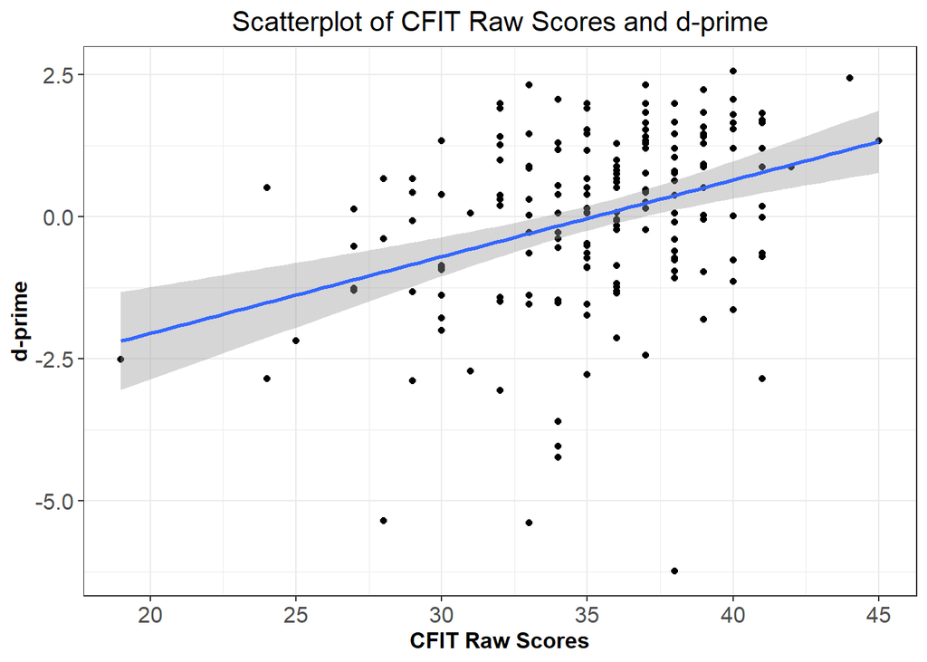

```r
# Create a scatterplot
Nback.dprime %>%
  ggplot(aes(x = CFIT, y = d.prime)) +
  geom_point() +
  geom_smooth(method = "lm") +
  theme_bw() +
  labs(title = "Scatterplot of CFIT Raw Scores and d-prime",
       x = "CFIT Raw Scores",
       y = "d-prime") +
  theme(plot.title = element_text(size = 15,
                                  hjust = 0.5),
        axis.title = element_text(size = 12, face = "bold"),
        axis.text = element_text(size = 12))
```

With visual inspection these both look good, but it seems the d prime model has much larger outliers than expected.

### Run the regression models

```r
# Run the regression with target as the outcome
target.regression <- lm(target.mean.reacted ~ CFIT + Sex + Age, data = Nback.performance.merged)

# Summary of the model
summary(target.regression)
```

```
Call:
lm(formula = target.mean.reacted ~ CFIT + Sex + Age, data = Nback.performance.merged)

Residuals:
    Min      1Q  Median      3Q     Max
-0.2237 -0.1835 -0.1419  0.1678  0.7814

Coefficients:
                    Estimate Std. Error t value Pr(>|t|)
(Intercept)       -0.0041582  0.1277486  -0.033   0.9740
CFIT               0.0047776  0.0027945   1.710   0.0879 .
SexIntersex/Other  0.0572135  0.1550787   0.369   0.7123
SexMale            0.0370590  0.0236282   1.568   0.1174
Age               -0.0002827  0.0037689  -0.075   0.9402
---
Signif. codes:  0 '***' 0.001 '**' 0.01 '*' 0.05 '.' 0.1 ' ' 1

Residual standard error: 0.2667 on 532 degrees of freedom
Multiple R-squared:  0.0122,    Adjusted R-squared:  0.004771
F-statistic: 1.642 on 4 and 532 DF,  p-value: 0.1622
```

```r
# Run the regression with d prime as the outcome
dprime.regression <- lm(d.prime ~ CFIT + Sex + Age, data = Nback.dprime)

# Summary of the model
summary(dprime.regression)
```

```
Call:
lm(formula = d.prime ~ CFIT + Sex + Age, data = Nback.dprime)

Residuals:
    Min      1Q  Median      3Q     Max
-6.7568 -0.6900  0.2631  0.9459  2.4198

Coefficients:
                  Estimate Std. Error t value Pr(>|t|)
(Intercept)       -5.03392    1.21708  -4.136 5.49e-05 ***
CFIT               0.12893    0.02662   4.843 2.82e-06 ***
SexIntersex/Other  0.80335    1.47745   0.544    0.587
SexMale            0.33200    0.22511   1.475    0.142
Age                0.01435    0.03591   0.400    0.690
---
Signif. codes:  0 '***' 0.001 '**' 0.01 '*' 0.05 '.' 0.1 ' ' 1

Residual standard error: 1.467 on 174 degrees of freedom
Multiple R-squared:  0.1443,    Adjusted R-squared:  0.1246
F-statistic: 7.335 on 4 and 174 DF,  p-value: 1.757e-05
```

### Regression Conlusion

From the two models, the one that uses d.prime as an outcome variable was significant, with a p < .001 and an R^2 of .14. When looking at predictors, CFIT was significant and our demographics information was not.

### Plot the Residuals

Now let’s plot the residuals of the model to determine whether we can use this statistical analysis or have to switch to something more robust, or maybe even non-parametric.

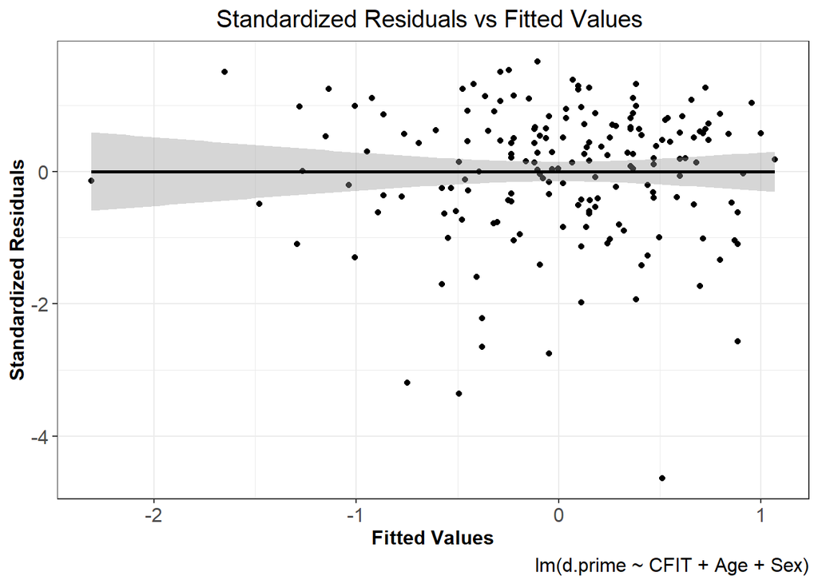

```r
# Add standardized residuals to our data frame
Nback.dprime$standardized.residuals <- rstandard(dprime.regression)

# Add fitted values to our data frame
Nback.dprime$fitted.values <- dprime.regression$fitted.values

# Create a graph using the fitted values and the standardized residuals
Nback.dprime %>%
  ggplot(aes(x = fitted.values, y=standardized.residuals)) +
  geom_point() +
  geom_smooth(method = "lm", color = "black") +
  theme_bw() +
  labs(title = "Standardized Residuals vs Fitted Values ",
       x = "Fitted Values",
       y = "Standardized Residuals",
       caption = "lm(d.prime ~ CFIT + Age + Sex)") +
  theme(plot.title = element_text(size = 15,
                                  hjust = 0.5),
        axis.title = element_text(size = 12, face = "bold"),
        axis.text = element_text(size = 12),
        plot.caption = element_text(size = 12))
```

There seems to be an outlier kinda, but overall I think this is good enough!!!

### Model for reaction time

We are now interest to see if the CFIT and the reaction time of correct Target trials are related to each other. It could potentially go both ways or not be significant at all. It could be possible that people with higher CFIT raw scores are faster at hitting target trials, it could also be that they are slower since they take the extra time to really verifiy if that is in fact a target trial or not, to reduce the chance of engaging in false alarms.

Regardless, to test this we will be using a regression as well with CFIT raw score as the predictor and mean reaction times to correct target trials per person.

### Visualizing the data

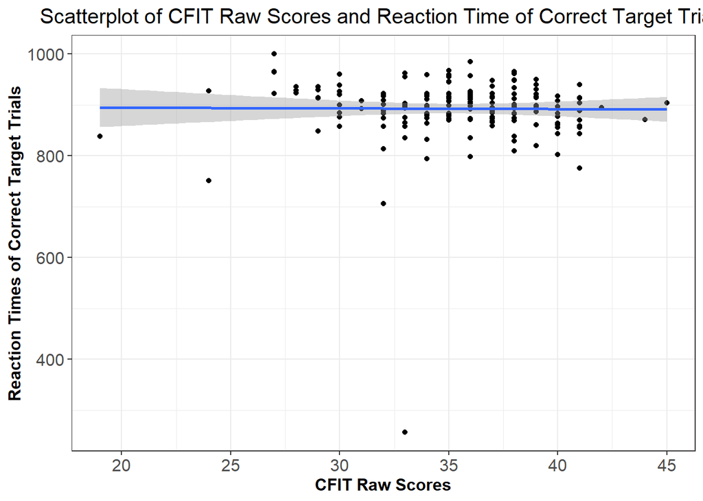

```r
# Create a scatterplot
Nback.reaction.time.merged %>%
  ggplot(aes(x = CFIT, y = mean.RT)) +
  geom_point() +
  geom_smooth(method = "lm") +
  theme_bw() +
  labs(title = "Scatterplot of CFIT Raw Scores and Reaction Time of Correct Target Trials",
       x = "CFIT Raw Scores",
       y = "Reaction Times of Correct Target Trials") +
  theme(plot.title = element_text(size = 15,
                                  hjust = 0.5),
        axis.title = element_text(size = 12, face = "bold"),
        axis.text = element_text(size = 12))
```

### Run the regression

```r
# Run the regression for reaction time
RT.regression <- lm(mean.RT ~ CFIT + Sex + Age, data = Nback.reaction.time.merged)

# Summary of the model
summary(RT.regression)
```

```
Call:
lm(formula = mean.RT ~ CFIT + Sex + Age, data = Nback.reaction.time.merged)

Residuals:
    Min      1Q  Median      3Q     Max
-642.33  -18.79    5.61   26.66  111.00

Coefficients:
                  Estimate Std. Error t value Pr(>|t|)
(Intercept)       887.8725    53.9630  16.453   <2e-16 ***
CFIT                0.1204     1.1892   0.101    0.919
SexIntersex/Other   9.9504    65.0397   0.153    0.879
SexMale           -11.9628     9.9568  -1.201    0.231
Age                 0.3234     1.5826   0.204    0.838
---
Signif. codes:  0 '***' 0.001 '**' 0.01 '*' 0.05 '.' 0.1 ' ' 1

Residual standard error: 64.56 on 172 degrees of freedom
Multiple R-squared:  0.008808,  Adjusted R-squared:  -0.01424
F-statistic: 0.3821 on 4 and 172 DF,  p-value: 0.8212
```

### Looking at both Accuracy and Reaction Time

Merge the datasets into one large one

```r
# Clean the dprime data set
Nback.dprime2 <- Nback.dprime %>% select(ID, d.prime, CFIT)

# Clean the reaction time dataset
Nback.reaction.time.merged2 <- Nback.reaction.time.merged %>% select(ID, BlockName, mean.RT)

# Merge the data sets
all.Nback.data <- Nback.dprime2 %>%
  merge(Nback.reaction.time.merged2, by = "ID")
```

..ignore this for now- I need to learn more stats first.